# Spatial Distortions

Gemma Holt

9/18/2020

# Projections and Distortions

## Setup

```r
library(tidyverse)
library(ggplot2)
library(ggthemes)
library (rnaturalearth)
library(cartogram)
library(sf)
library(ggspatial)
library(rnaturalearthdata)
library(viridis)
library(dplyr)
```

### Finland Base Map

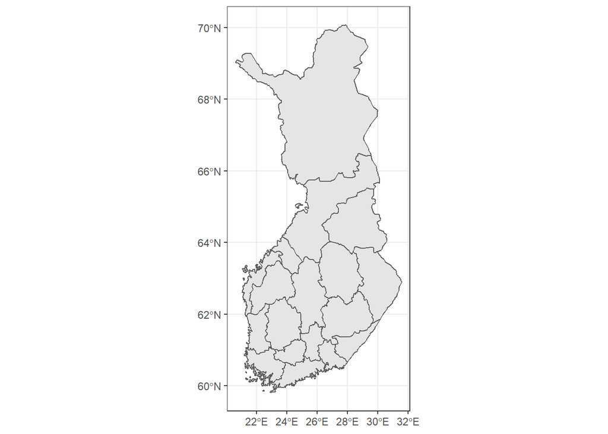

```r
finland_regions <- ne_states(country= "Finland", returnclass= "sf")

finland_map <- ggplot(finland_regions) +
  geom_sf()+
  theme_bw()

finland_map
```

## Projections

Finland has a national coordinate system based on the Hayford ellipsoid (1924) and transverse Mercator projection. For the most part this system was replaced with a pan-European system in 2005, but I was interested in looking at the differences. I am also interested in polar politics and so I chose two projections that are designed for the Arctic and Antarctic.

```r
finn_UCS <- "+proj=tmerc +lat_0=0 +lon_0=27 +k=1 +x_0=3500000 +y_0=0 +ellps=intl +units=m +no_defs"

finn_zone0 <- "+proj=tmerc +lat_0=0 +lon_0=18 +k=1 +x_0=500000 +y_0=0 +ellps=intl +units=m +no_defs"

finn_zone5 <- "+proj=tmerc +lat_0=0 +lon_0=33 +k=1 +x_0=5500000 +y_0=0 +ellps=intl +units=m +no_defs"

finn_arctic <- "+proj=stere +lat_0=90 +lat_ts=71 +lon_0=0 +k=1 +x_0=0 +y_0=0 +ellps=WGS84 +datum=WGS84 +units=m +no_defs"

finn_antarctic <- "+proj=stere +lat_0=-90 +lat_ts=-71 +lon_0=0 +k=1 +x_0=0 +y_0=0 +ellps=WGS84 +datum=WGS84 +units=m +no_defs"

finn_weird <- "+proj=tmerc +lat_0=-34.629269 +lon_0=-58.4633 +k=0.9999980000000001 +x_0=100000 +y_0=100000 +ellps=intl +units=m +no_defs "
```

### Finland Uniform Coordinate System

This is the standard projection from the Finnish coordinate system.

```r
finland_UCS <- ggplot(finland_regions)+
  geom_sf() +
  coord_sf(crs = finn_UCS) +
  theme_bw()+
xlab("Longitude") + ylab("Latitude") +
    ggtitle("Finland")

png(file="C:/Users/gemma/OneDrive/GSD Semester 1/Spatial Analysis/Final Portfolio/Figures/finlanducs.png",
width=350, height=600)
finland_UCS
dev.off()
```

### Finland Zone 0

This zone is designed for mapping the western-most (Sweden-adjacent) part of Finland.

```r
finland_zone0 <- ggplot(finland_regions)+
  geom_sf() +
  coord_sf(crs = finn_zone0) +
  theme_bw()+
  xlab("Longitude") + ylab("Latitude") +
    ggtitle("Finland", subtitle="Zone 0")

png(file="C:/Users/gemma/OneDrive/GSD Semester 1/Spatial Analysis/Final Portfolio/Figures/finland_zone0.png",
width=350, height=600)
finland_zone0
dev.off()
```

### Finland Zone 5

This zone is designed for mapping the eastern-most (Russia-adjacent) part of Finland.

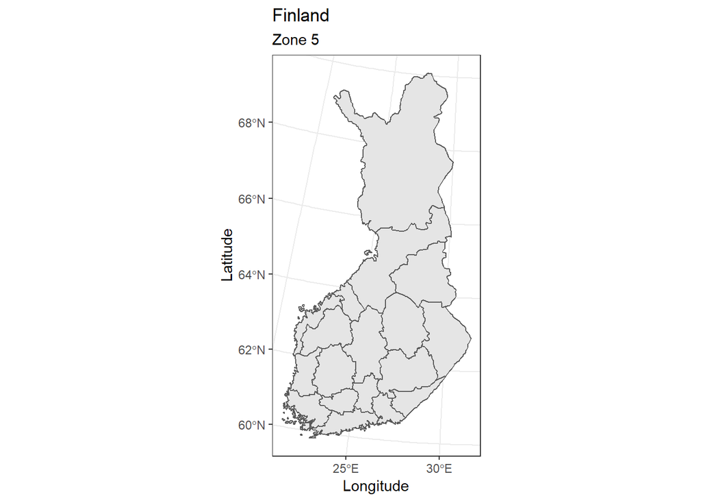

```r
ggplot(finland_regions)+
  geom_sf() +
  coord_sf(crs = finn_zone5) +
  theme_bw()+
  xlab("Longitude") + ylab("Latitude") +
    ggtitle("Finland", subtitle="Zone 5")
```

### Arctic Polar Stereograph

This projection is intended to be used in Northern hemisphere - north of 60°N onshore and offshore, including the Arctic Ocean.

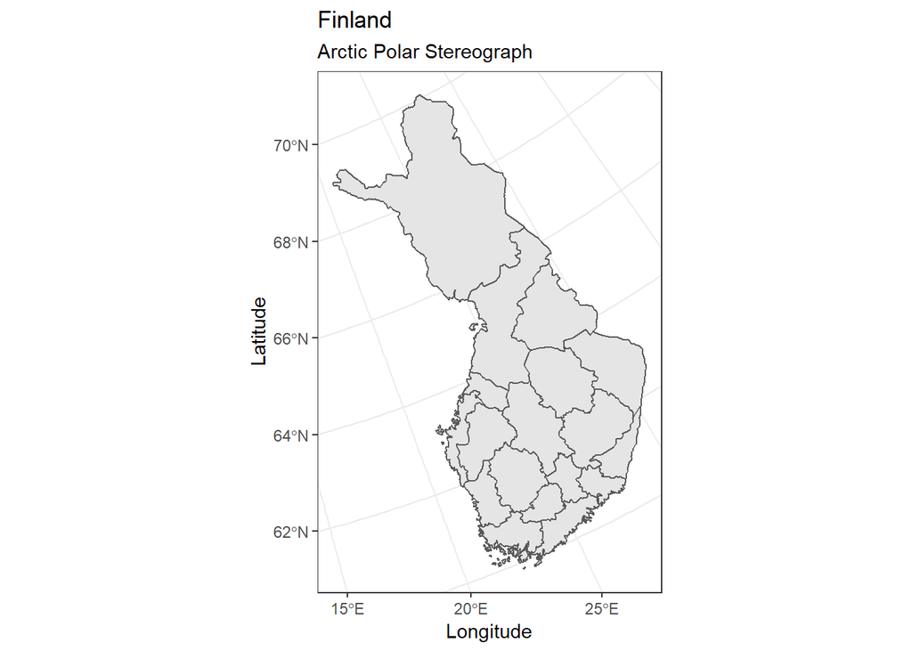

```r
finland_arctic <- ggplot(finland_regions)+
  geom_sf() +
  coord_sf(crs = finn_arctic) +
  theme_bw()+
  xlab("Longitude") + ylab("Latitude") +
    ggtitle("Finland", subtitle="Arctic Polar Stereograph")

finland_arctic
```

```r
png(file="C:/Users/gemma/OneDrive/GSD Semester 1/Spatial Analysis/Final Portfolio/Figures/finland_arctic.png",
width=350, height=600)
finland_arctic
dev.off()
```

### Antarctic Polar Stereograph

This projection is intended to be used in Antarctica. I was interested in comparing the projections between the North and South Poles and was surprised that using an Antarctic projection did not have a significant impact on the legibility of the map.

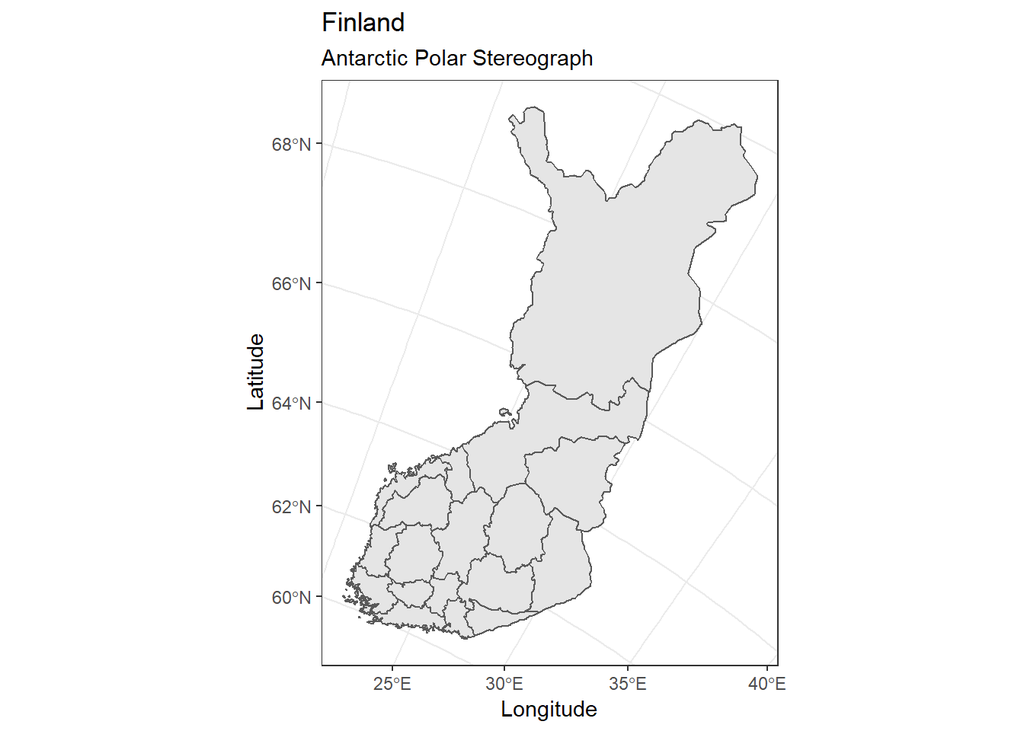

```r
finland_antarctic <- ggplot(finland_regions)+
  geom_sf() +
  coord_sf(crs = finn_antarctic) +
  theme_bw()+
  xlab("Longitude") + ylab("Latitude") +
    ggtitle("Finland", subtitle="Antarctic Polar Stereograph")

finland_antarctic
```

```r
png(file="C:/Users/gemma/OneDrive/GSD Semester 1/Spatial Analysis/Final Portfolio/Figures/finland_antarctic.png",
width=350, height=600)
finland_antarctic
dev.off()
```

### Argentina State Plane

Since all of these maps look quite similar, I thought I’d try a projection that has no relationship to Finland. This projection is intended for use in Argentina.

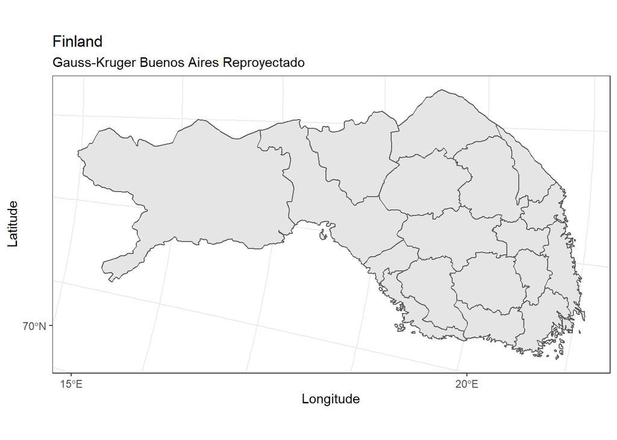

```r
ggplot(finland_regions)+
  geom_sf() +
  coord_sf(crs = finn_weird) +
  theme_bw()+
  xlab("Longitude") + ylab("Latitude") +
    ggtitle("Finland", subtitle="Gauss-Kruger Buenos Aires Reproyectado")
```

## Transforming coordinate systems

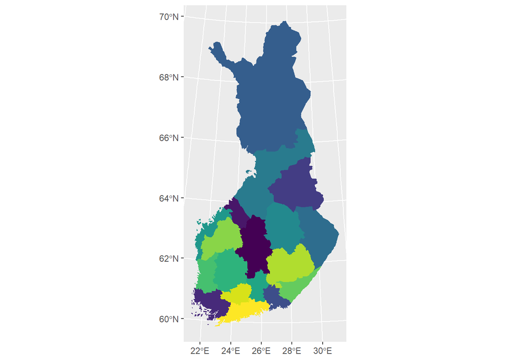

```r
regions_transformed <- finland_regions %>%
  st_transform(crs = finn_UCS)

ggplot(regions_transformed, aes(fill = name)) +
  geom_sf(color = NA) +
  scale_fill_viridis_d()+
  theme(legend.position = "none")
```

## Analyzing immigration data

I downloaded regional population and immigration data from Statistics Finland. I ran into a problem since the csv file was not exporting umlauts. I addressed most of the issues in the csv, excluding the data for  
Päijät-Häme which I changed manually.

```r
finn_migrate <- read_csv("C:\\Users\\gemma\\Desktop\\gemmaholt-vis\\Assignment-2_files\\FinlandImmigration2.csv")

finland_skinny <- finland_regions %>%
  select(name, latitude, longitude, geometry)
view(finland_skinny)

finland_merge <- left_join(finland_skinny,finn_migrate, by="name")
View(finland_merge)

finland_merge[18,4] = 199604
finland_merge[18,5] = 11135

finland_merge <- mutate(finland_merge, pct_migrate=100*var_migrate/var_pop)

finland_merge <- mutate(finland_merge,migrate_10k=var_migrate/1000)
```

### Population born abroad

This map shows the population in each administrative region that was born abroad. Most foreign-born persons live near Helsinki (the yellow part of the map) and there is very little immigration outside of this region. It’s not a very interesting map because of this!

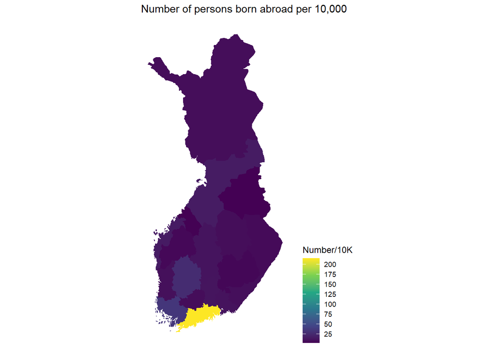

```r
ggplot(finland_merge, aes(fill = migrate_10k))+
geom_sf(color = NA) +
  scale_fill_viridis_c(
    name = "Number/10K",
    breaks = seq(0, 2500, by = 25),
    labels = formatC(seq(0, 2500, by = 25))) +
  theme_map() +
  theme(legend.background = element_blank(),legend.position="right",
        legend.title = element_text(size=9)) +
    ggtitle("Number of persons born abroad per 10,000")
```

### Population born abroad (log scale)

To address that, I graphed the same variable on a logarithmic scale instead of a linear scale, which produces a much more colorful map.

```r
lseq <- function(from=1, to=100000, length.out=6) {
  # logarithmic spaced sequence
  # blatantly stolen from library("emdbook"), because need only this
  # I blatantly stole this from https://stackoverflow.com/questions/23901907/create-a-log-sequence-across-multiple-orders-of-magnitude
  exp(seq(log(from), log(to), length.out = length.out))
}
```

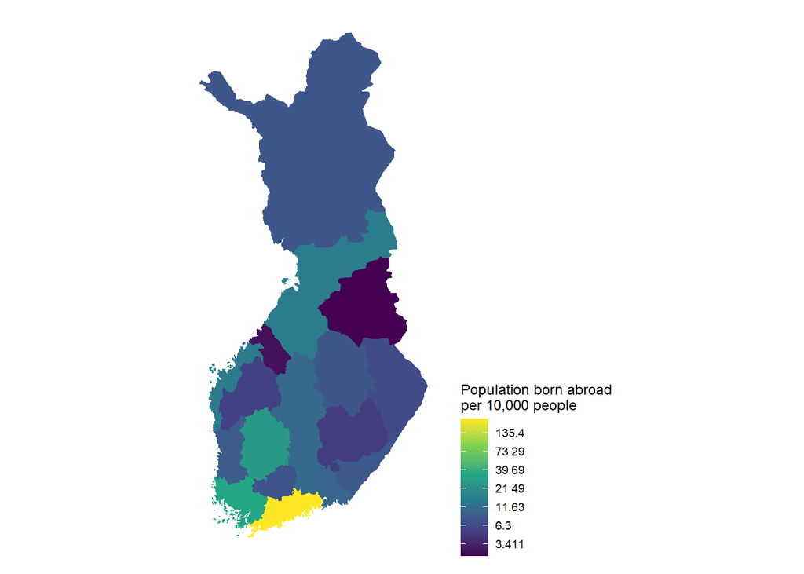

```r
finland_migrate <- ggplot(finland_merge, aes(fill = migrate_10k))+
geom_sf(color = NA) +
  scale_fill_viridis_c(trans = "log",
    name = "Population born abroad\nper 10,000 people",
    breaks = lseq(1, 250, 10),
    labels = formatC(lseq(1, 250, 10))) +
  theme_map() +
  theme(legend.background = element_blank(),legend.position="right",
        legend.title = element_text(size=9)) +
  theme(text = element_text(family = "Verdana"))

finland_migrate
```

```r
png(file="C:/Users/gemma/OneDrive/GSD Semester 1/Spatial Analysis/Final Portfolio/Figures/finland_migrate.png",
  width = 5,
  height    = 7,
  units     = "in",
  res       = 1000)
finland_migrate
dev.off()
```

### Percent born abroad

I also mutated the same data to show the percentage of persons born abroad. I’m interested in understanding how you can produce different maps with the same data in order to uphold a particular narrative.

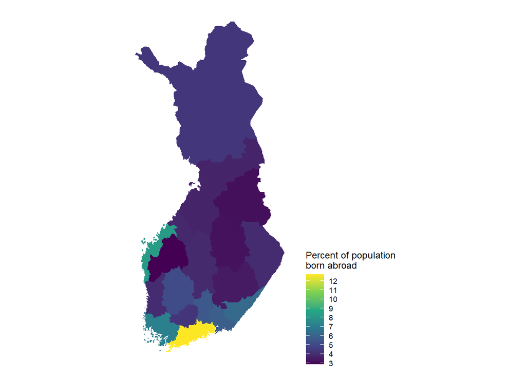

```r
finland_pctmigrate <- ggplot(finland_merge, aes(fill = pct_migrate))+
geom_sf(color = NA) +
  scale_fill_viridis_c(
    name = "Percent of population\nborn abroad",
    breaks = seq(0, 12, by = 1),
    labels = formatC(seq(0, 12, by = 1))) +
  theme_map() +
  theme(legend.background = element_blank(),legend.position="right",
        legend.title = element_text(size=9))

finland_pctmigrate
```

```r
png(file="C:/Users/gemma/OneDrive/GSD Semester 1/Spatial Analysis/Final Portfolio/Figures/finland_pctmigrate.png",
  width = 5,
  height    = 7,
  units     = "in",
  res       = 1000)
finland_pctmigrate
dev.off()
```

### Density equalized plot

```r
library(cartogram)
migrate_cartogram_cont <- finland_merge %>%
  st_transform(crs = finn_UCS) %>%
  cartogram_cont("var_migrate")
```

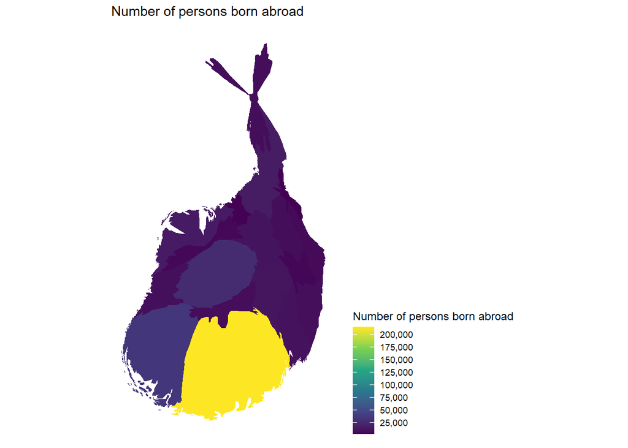

```r
finland_whale <- ggplot(migrate_cartogram_cont, aes(fill = var_migrate)) +
  geom_sf(color = NA) +
  scale_fill_viridis_c(
    name = "Number of persons born abroad",
    breaks = seq(0, 250000, by = 25000),
    labels = formatC(seq(0, 250000, by = 25000),
                     big.mark = ",", format = "f", digits = 0)) +
  theme_map() +
  theme(legend.background = element_blank(),legend.position="right",
        legend.title = element_text(size=9)) +
    ggtitle("Number of persons born abroad")

finland_whale
```

```r
png(file="C:/Users/gemma/OneDrive/GSD Semester 1/Spatial Analysis/Final Portfolio/Figures/finland_whale.png",
width = 4,
  height    = 6,
  units     = "in",
  res       = 1000)
finland_whale
dev.off()
```

### Centroid map

```r
migrate_centeroids <- finland_merge %>%
  st_centroid(crs = finn_UCS)
```

```r
finland_centroid <- ggplot(finland_merge) +
  geom_sf(fill = NA, color = "darkgray") +
  geom_sf(data = migrate_centeroids,
          aes(size = var_migrate),
          alpha = 0.5, color = "blue") +
  scale_size_continuous(name = "Number",
    breaks = seq(0, 250000, by = 50000),
    labels = formatC(seq(0, 250000, by = 50000),
                     big.mark = ",", format = "f", digits = 0),
    range = c(0, 20)) +
  ggtitle("Number of persons born abroad")+
  theme_void()

png(file="C:/Users/gemma/OneDrive/GSD Semester 1/Spatial Analysis/Final Portfolio/Figures/finland_centroid.png",
  width = 5,
  height    = 7,
  units     = "in",
  res       = 1000)
finland_centroid
dev.off()
```